# Model Selection & Controls

Natasha Kang

Xiamen University, Chow Institute

April, 2026

## Two Goals of Econometrics

|  | **Prediction** | **Causality** |
| --- | --- | --- |
| Question | “What will happen?” | “What would happen if…?” |
| Focus | Accuracy | Isolation of effects |
| Needs | Correlates | Exogenous variation |
| Metric | MSE | Unbiasedness |

- A good prediction model may be a bad causal model, and vice versa.
- The tools for choosing variables differ depending on the goal.

## The Prediction Problem

**Recall** (lect2a): the CEF $E[y \mid \mathbf{x}]$ is the best predictor of $y$ given $\mathbf{x}$ under MSE.

But we don’t know the CEF — we estimate it:

$$\hat{y} = \hat{\beta}_0 + \hat{\beta}_1 x_1 + \cdots + \hat{\beta}_k x_k$$

The prediction error $y_{\text{new}} - \hat{y}_{\text{new}}$ comes from two sources:

1. **Model approximation**: our linear model may not capture the true CEF.
2. **Estimation uncertainty**: $\hat{\boldsymbol{\beta}}$ is estimated from a finite sample.

Adding regressors can reduce (1) but worsens (2). How do we navigate this tradeoff?

## Why the “True” Model Isn’t Always Best

**Example**: predicting GDP growth.

$$\text{GDP}_t = \alpha + \beta_1\, \text{Investment}_t + \beta_2\, \text{Innovation}_t + u_t$$

- $\text{Innovation}_t$ is hard to measure — noisy proxy.
- Including it adds **estimation uncertainty** (source 2) to predictions.
- A simpler model omitting $\text{Innovation}_t$ has higher bias (source 1) but lower variance (source 2).
- If the variance reduction outweighs the bias increase, the simpler model predicts better.

This is the **bias-variance tradeoff** — the central idea of predictive model selection.

## The Bias-Variance Tradeoff: Setup

True relationship: $y = f(\mathbf{x}) + u$, where $E[u \mid \mathbf{x}] = 0$ and $\text{Var}(u \mid \mathbf{x}) = \sigma^2$.

We fit a model $\hat{y}(\mathbf{x})$ to training data and use it to predict a new observation $(y_{\text{new}}, \mathbf{x}_{\text{new}})$. Our prediction error is:

$$y_{\text{new}} - \hat{y}(\mathbf{x}_{\text{new}}) = \underbrace{f(\mathbf{x}_{\text{new}}) - \hat{y}(\mathbf{x}_{\text{new}})}_{\text{model error}} + \underbrace{u_{\text{new}}}_{\text{noise}}$$

Since $u_{\text{new}}$ is independent of $\hat{y}$, squaring and taking expectations:

$$\text{MSE}_{\text{out}} = E[(\hat{y} - y)^2] = \underbrace{E[(\hat{y} - f(\mathbf{x}))^2]}_{\text{model error}} + \underbrace{\sigma^2}_{\text{irreducible error}}$$

We cannot reduce $\sigma^2$ — it is the inherent noise in $y$. The question is how to minimize model error.

## Deriving the Bias-Variance Decomposition

Fix a point $\mathbf{x}$ and consider the model error $\hat{y}(\mathbf{x}) - f(\mathbf{x})$. The only randomness is in $\hat{y}$ (which depends on the training sample). Add and subtract $E[\hat{y}]$:

$$\hat{y} - f(\mathbf{x}) = \bigl(\hat{y} - E[\hat{y}]\bigr) + \bigl(E[\hat{y}] - f(\mathbf{x})\bigr)$$

Square and take expectations over the training sample. Since $E[\hat{y}]$ and $f(\mathbf{x})$ are both non-random (for fixed $\mathbf{x}$), the second term is a constant $b \equiv E[\hat{y}] - f(\mathbf{x})$:

$$E[(\hat{y} - f(\mathbf{x}))^2] = E[(\hat{y} - E[\hat{y}])^2] + 2b\,\underbrace{E[\hat{y} - E[\hat{y}]]}_{= 0} + b^2$$

The cross term vanishes, leaving:

$$E[(\hat{y} - f(\mathbf{x}))^2] = \underbrace{E[(\hat{y} - E[\hat{y}])^2]}_{\text{Variance}} + \underbrace{(E[\hat{y}] - f(\mathbf{x}))^2}_{\text{Bias}^2}$$

## The Full Decomposition

Putting it together:

$$\text{MSE}_{\text{out}} = \underbrace{(E[\hat{y}] - f(\mathbf{x}))^2}_{\text{Bias}^2} + \underbrace{E[(\hat{y} - E[\hat{y}])^2]}_{\text{Variance}} + \underbrace{\sigma^2}_{\text{Irreducible}}$$

- **Bias**: how far the model’s *average* prediction is from the truth. Caused by wrong functional form or omitted variables — the model is systematically off.
- **Variance**: how much the prediction *fluctuates* across different training samples. Caused by estimation uncertainty — the model chases noise.
- **Irreducible error**: noise in $y$ itself. No model can eliminate it.

## Bias vs. Variance: Intuition

- **Simple models** (few regressors): high bias, low variance.
  - Example: predicting wages with only *education* — misses a lot, but stable across samples.
- **Complex models** (many regressors): low bias, high variance.
  - Example: predicting wages with 50 variables including ZIP code and birth month — flexible, but erratic.
- The **optimal model** balances the two: complex enough to capture the signal, simple enough to not chase noise.
- All model selection tools (adjusted $R^2$, AIC, BIC, cross-validation) are attempts to find this balance.

## Visualizing the Tradeoff

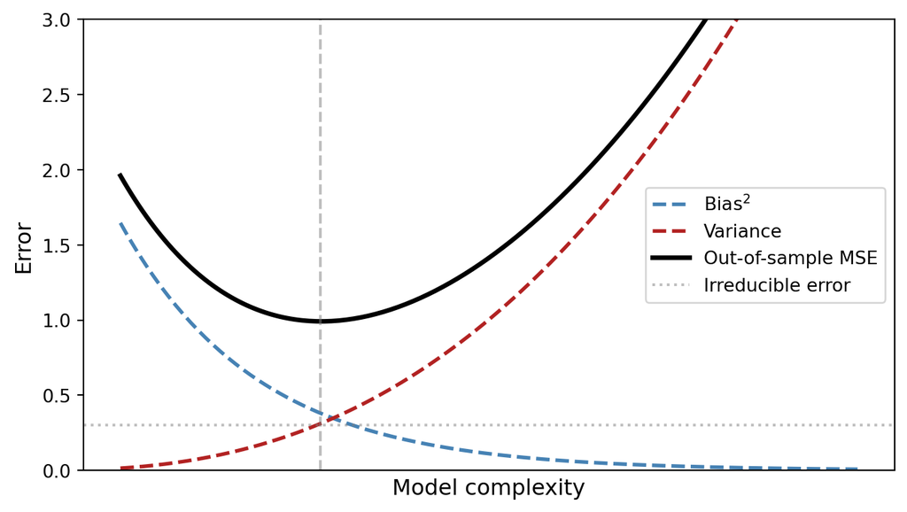

An optimal complexity exists — but we cannot observe bias and variance separately. What does overfitting *look like* in practice?

## Overfitting in Action

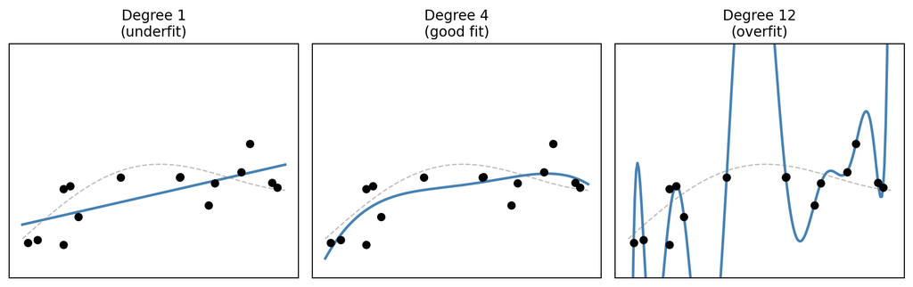

- **Left**: too simple — misses the curvature (high bias).
- **Middle**: captures the pattern without chasing noise.
- **Right**: passes through every point but oscillates wildly — will predict poorly on new data (high variance).

The degree-12 model has near-zero in-sample error — but terrible out-of-sample performance. We need a way to measure the difference.

## In-Sample vs. Out-of-Sample

- **In-sample MSE**: how well the model fits the training data.

$$\text{MSE}_{\text{in}} = \frac{1}{n} \sum_{i=1}^n (y_i - \hat{y}_i)^2$$

- A model can always reduce in-sample MSE by adding more regressors — even irrelevant ones.
- This is **overfitting**: the model fits noise, not signal.
- **Out-of-sample MSE**: how well the model predicts new data. This is the true test.

$$\text{MSE}_{\text{out}} = E[(y_{\text{new}} - \hat{y}_{\text{new}})^2]$$

## Estimating Out-of-Sample MSE

We cannot observe $\text{MSE}_{\text{out}}$ directly. Two practical approaches:

**Holdout method**: split data into training set and test set.

- Fit the model on the training set.
- Evaluate predictions on the test set.
- Simple, but wastes data and results depend on the particular split.

**$k$-fold cross-validation**: split data into $k$ subsets (folds).

- For each fold: train on the other $k-1$ folds, predict the held-out fold.
- Average the $k$ test MSEs.
- Uses all data for both training and evaluation. More stable, but computationally heavier.

An alternative: instead of splitting the data, **penalize** in-sample fit for model complexity. This is the idea behind adjusted $R^2$, AIC, and BIC.

## Adjusted $R^2$

$R^2$ always increases when adding regressors — even useless ones. The **adjusted $R^2$** penalizes for model complexity:

$$\bar{R}^2 = 1 - \frac{SSR/(n - k - 1)}{SST/(n - 1)}$$

- Unlike $R^2$, $\bar{R}^2$ can **decrease** when an added variable does not sufficiently improve fit.
- Prefer the model with higher $\bar{R}^2$.

## Example: R&D Intensity and Firm Sales

Consider explaining R&D spending as a share of sales ($\textit{rdintens}$):

|  | Model 1 | Model 2 | Model 3 |
| --- | --- | --- | --- |
| $\log(\textit{sales})$ | $-0.673$ | $-1.117$ | $-0.571$ |
| $\textit{profmarg}$ |  | $0.174$ | $0.175$ |
| $\log(\textit{sales})^2$ |  |  | $-0.037$ |
| $R^2$ | $0.061$ | $0.148$ | $0.155$ |
| $\bar{R}^2$ | $0.030$ | $0.091$ | $0.066$ |

- $R^2$ increases from Model 2 to Model 3, but $\bar{R}^2$ **decreases** — the squared term does not improve fit enough to justify the added parameter.
- $\bar{R}^2$ selects Model 2.

## Question

*Can we use $\bar{R}^2$ to choose between $y$ and $\log(y)$ as the dependent variable?*

**No.** $\bar{R}^2$ measures the proportion of variation explained relative to the total variation *in the dependent variable*. Since $\text{Var}(y) \neq \text{Var}(\log(y))$, the SST differs across models and the $\bar{R}^2$ values are not comparable.

## Information Criteria

An alternative approach: penalize the log-likelihood for model complexity. Here $k$ is the total number of estimated parameters (including the intercept).

**AIC** (Akaike):

$$\text{AIC} = -2 \log \hat{L} + 2k$$

**BIC** (Bayesian / Schwarz):

$$\text{BIC} = -2 \log \hat{L} + k \log n$$

- Lower is better. Both trade off fit ($-2\log\hat{L}$) against complexity ($k$).
- BIC penalizes more heavily for $n > 7$ (since $\log n > 2$), favoring simpler models.
- For linear regression with normal errors: $-2\log\hat{L} \propto n\log(SSR/n)$.

## RESET: Testing Functional Form

The **Regression Equation Specification Error Test** (Ramsey, 1969) checks whether the model misses nonlinearities.

**Idea**: if the model $y = \mathbf{x}\boldsymbol{\beta} + u$ is correctly specified, powers of the fitted values $\hat{y}^2, \hat{y}^3$ should have no additional explanatory power.

**Procedure**:

1. Estimate the original model. Obtain $\hat{y}_i$.
2. Run the auxiliary regression: $y_i = \mathbf{x}_i\boldsymbol{\gamma} + \alpha_2 \hat{y}_i^2 + \alpha_3 \hat{y}_i^3 + u_i$.
3. Test $H_0: \alpha_2 = \alpha_3 = 0$ using an $F$-test.
- Rejection suggests functional form misspecification (e.g., missing quadratics, logs, interactions).
- RESET does not tell you *what* is wrong — only that something is.

## RESET: Example

**Housing prices**: $\log(\textit{price}) = \beta_0 + \beta_1\, \textit{sqrft} + \beta_2\, \textit{bdrms} + u$.

Step 1: Estimate the model. Obtain $\hat{y}_i$.

Step 2: Auxiliary regression:

$$\log(\textit{price}_i) = \gamma_0 + \gamma_1\, \textit{sqrft}_i + \gamma_2\, \textit{bdrms}_i + \alpha_2 \hat{y}_i^2 + \alpha_3 \hat{y}_i^3 + u_i$$

Step 3: $F$-test of $H_0: \alpha_2 = \alpha_3 = 0$.

- If $F = 4.67$ with $p = 0.012$: reject $H_0$. The linear specification is inadequate.
- Next step: try $\textit{sqrft}^2$, $\log(\textit{sqrft})$, or interactions (lect4a tools).

## Comparing Nested Models: $F$-test

**Recall** (lect3a): to compare a restricted model against an unrestricted model, use the $F$-test.

**Example**: Is a quadratic wage model better than a linear one?

$$\text{Model 1}: \log(\textit{wage}) = \beta_0 + \beta_1\, \textit{exper} + u$$

$$\text{Model 2}: \log(\textit{wage}) = \beta_0 + \beta_1\, \textit{exper} + \beta_2\, \textit{exper}^2 + u$$

- Model 1 is nested in Model 2. Test $H_0: \beta_2 = 0$.
- Here a $t$-test suffices (one restriction). For multiple restrictions, use the $F$-test:

$$F = \frac{(SSR_r - SSR_{ur}) / q}{SSR_{ur} / (n - k - 1)} \sim F_{q, n-k-1}$$

where $q$ = number of restrictions.

## Predictive Model Selection: Summary

| Tool | What it does | Limitation |
| --- | --- | --- |
| Adjusted $R^2$ | Penalizes for $k$ | Cannot compare different $y$’s |
| AIC / BIC | Penalizes log-likelihood | Requires same $y$; BIC may underfit |
| $F$-test (lect3a) | Compares nested models | Requires nesting |
| RESET | Detects misspecification | Does not identify the fix |

All of these are tools for **prediction**. For **causal** questions, the criteria are fundamentally different.

## From Prediction to Causality

For prediction, we want the model that minimizes MSE — we don’t care *why* a variable is correlated, only that it helps forecast.

For causality, we want to isolate the effect of a treatment $T$ on an outcome $Y$. Including the wrong controls can **introduce** bias rather than remove it.

The question is no longer “does this variable improve fit?” but rather: **does conditioning on this variable help identify the causal effect?**

## Example: Job Training and Productivity

A firm wants to estimate the causal effect of a job training program on employee productivity.

Training is randomly assigned. The naive comparison is unbiased:

$$E[Y_i \mid T_i = 1] - E[Y_i \mid T_i = 0] = E[Y_{1i} - Y_{0i}] = \text{ATE}$$

Should we also control for **post-training test scores**? They are correlated with productivity — so they would improve prediction.

**No.**

## Bad Control: The Potential Outcomes View

Let $B_i$ be an indicator for a high post-training test score (e.g., above the median). Conditioning on $B_i$:

$$\begin{aligned}
&E[Y_i \mid B_i = 1, T_i = 1] - E[Y_i \mid B_i = 1, T_i = 0] \\
= \;& E[Y_{1i} \mid B_{1i} = 1] - E[Y_{0i} \mid B_{0i} = 1] \\
= \;& \underbrace{E[Y_{1i} - Y_{0i} \mid B_{1i} = 1]}_{\text{CATE}} + \underbrace{E[Y_{0i} \mid B_{1i} = 1] - E[Y_{0i} \mid B_{0i} = 1]}_{\text{selection bias}}
\end{aligned}$$

- The selection bias term is generally non-zero: having a high score under treatment ($B_{1i} = 1$) selects different people than having a high score under control ($B_{0i} = 1$).

## Why Does This Happen?

Post-training test scores depend on both **training** and **innate ability**.

Among workers with the *same* test score:

- Those who received training got that score *despite* possibly lower innate ability.
- Those who did not receive training got that score *because of* higher innate ability.
- So within each test-score group, the control group has systematically higher ability than the treated group.
- Higher ability $\to$ higher productivity $\to$ the treated–control comparison *understates* the training effect.
- Conditioning on test scores created a spurious link between training and ability — even though training was randomly assigned.
- **DAGs** give us a visual language to see when this happens in general.

## Directed Acyclic Graphs (DAGs)

A **Directed Acyclic Graph (DAG)** represents the causal structure:

- **Nodes** = variables
- **Arrows** = causal relationships
- **Acyclic** = no feedback loops

Three fundamental building blocks:

|  | Pattern |  | Role of $M$ |
| --- | --- | --- | --- |
| **Chain** | $X \to M \to Y$ |  | Mediator |
| **Fork** | $X \leftarrow M \to Y$ |  | Common cause (confounder) |
| **Collider** | $X \to M \leftarrow Y$ |  | Common effect |

## The Collider Problem

In the job training example, **Test Score (Post)** is a collider:

$$\text{Training} \to \text{Test Score} \leftarrow \text{Innate Ability}$$

- Without conditioning: Training and Ability are independent (random assignment). No bias.
- Conditioning on Test Score: among workers with the *same* score, Training and Ability become negatively associated — knowing one tells you about the other.
- This opens a spurious path from Training to Productivity through Ability.
- **General rule**: conditioning on a collider *creates* an association between its causes that did not exist before.

How do we determine when to control for a variable — and when not to?

## $d$-Separation

Let $Z$ be the set of variables we control for in the regression. A path between $X$ and $Y$ is **blocked** (d-separated) by $Z$ if:

- **Chain** $\to M \to$ or **fork** $\leftarrow M \to$:
  - Path is open by default. Including $M$ in $Z$ **blocks** it.
- **Collider** $\to M \leftarrow$:
  - Path is blocked by default. Including $M$ in $Z$ **opens** it.

If *all* paths between $X$ and $Y$ are blocked by $Z$, then $X \perp\!\!\!\perp Y \mid Z$: $X$ and $Y$ are conditionally independent given $Z$.

**For causal inference**: choose $Z$ so that all non-causal (back-door) paths between treatment and outcome are blocked, without opening collider paths.

## $d$-Separation: Examples

**Chain**: Rain $\to$ Wet Road $\to$ Accident

- Conditioning on Wet Road blocks the path from Rain to Accident.
- Once you know the road is wet, knowing whether it rained adds nothing about accident risk.

**Fork**: Parental Education $\to$ Parental Involvement; Parental Education $\to$ Child Performance

- Conditioning on Parental Education blocks the spurious association between Involvement and Performance.

**Collider**: Stress $\to$ Blood Pressure $\leftarrow$ Family History

- Stress and Family History are marginally independent.
- Conditioning on Blood Pressure **induces** a spurious association: among hypertensive patients, those without family history are more likely to be stressed.

## Can We Identify Mediators from Regression?

Suppose controlling for $M$ makes the coefficient on $T$ insignificant. Can we conclude that $M$ mediates the effect of $T$ on $Y$?

**No.** Two different causal structures produce the same regression pattern:

- **Mediation**: $T \to M \to Y$. Controlling for $M$ blocks the causal path.
- **Confounding**: $T \leftarrow M \to Y$. Controlling for $M$ removes a spurious association.

In both cases, the coefficient on $T$ shrinks or vanishes when $M$ is included. The regression cannot distinguish the two — you need to know the causal structure (the DAG).

This is why **theory matters**: the decision to control for a variable cannot be made on statistical grounds alone.

## The Job Training DAG

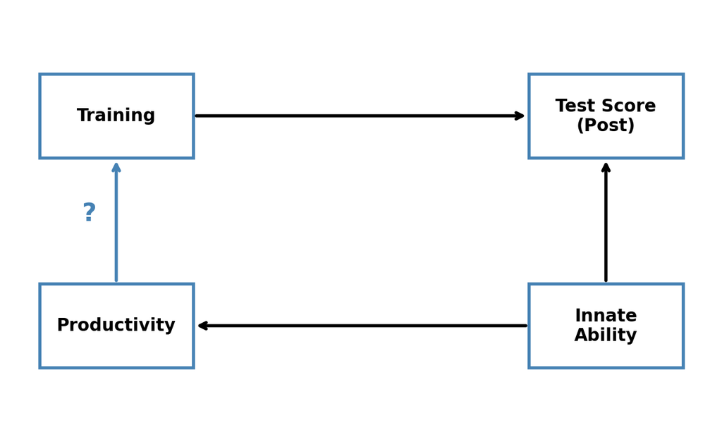

- **Test Score (Post)** is a **collider**: Training $\to$ Test Score $\leftarrow$ Ability.
- Conditioning on it **opens** a spurious path: Training $\to$ Test Score $\leftarrow$ Ability $\to$ Productivity.

## What About Pre-Training Test Scores?

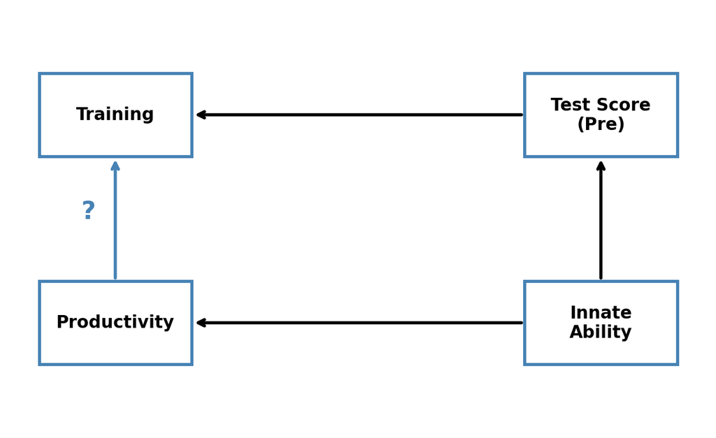

- **Test Score (Pre)** is part of a **chain**: Ability $\to$ Test Score (Pre) $\to$ Training.
- Conditioning on it **blocks** the back-door path: Ability $\to$ Test Score $\to$ Training.
- This is a **good control** — it removes confounding.

## Good Controls vs. Bad Controls

- **Good control**: a pre-treatment variable that blocks confounding paths without opening new ones.
- **Bad control**: a post-treatment variable that lies on the causal path or is a collider — conditioning on it introduces bias.

**Rules of thumb**:

1. Pre-treatment variables that are correlated with both $T$ and $Y$ are usually good controls.
2. Post-treatment variables — outcomes, mediators, or variables affected by treatment — are usually bad controls.
3. When in doubt, draw the DAG.

## Exercises: Good or Bad Control?

**Q1**: Returns to college education.

- Outcome: Earnings. Treatment: College graduation.
- Control? Occupation (white collar vs. blue collar).

**Q2**: Obesity and mortality.

- Outcome: Mortality. Treatment: Obesity.
- Control? Heart failure, diabetes. (The “obesity paradox.”)

## Exercises (cont.)

**Q3**: Beer tax and traffic fatalities.

- Outcome: Fatalities. Treatment: Beer tax.
- Control? Per capita beer consumption.

**Q4**: Attendance and final exam score.

- Outcome: Final exam score. Treatment: Attendance.
- Consider: *ACT*, *priGPA*, *termGPA*, *homework*.
- Which are good controls? Which are potentially bad?

**Q5**: Childhood nutrition and adult height.

- Outcome: Height. Treatment: Childhood nutrition.
- Control? Enlisted in military.

## Drawing the DAG Is Hard

The exercises above have no single “right” DAG — reasonable researchers can disagree.

- The DAG encodes your **theoretical assumptions** about the causal structure, not empirical findings.
- Different narratives about the same variables can justify different graphs — and therefore different control strategies.
- For example: does parental income affect child test scores directly, or only through school quality? If directly, school quality is a confounder. If only through school quality, it is a mediator. The DAG — and the control strategy — depends on which story you believe.
- When multiple stories are plausible, the DAG framework does not give a clear answer — and neither does any other approach.
- The value of the DAG is not that it resolves the ambiguity, but that it forces you to **state your assumptions explicitly** rather than burying them in a regression specification.

## Summary

- For **prediction**, more variables are not always better — the bias-variance tradeoff governs model complexity.
- Adjusted $R^2$, AIC/BIC, and RESET help select among models for predictive purposes.
- For **causality**, the question is not “does this variable improve fit?” but “does conditioning help identify the causal effect?”
- **Bad controls** (post-treatment variables, colliders) can introduce bias even in randomized experiments.
- **Good controls** (pre-treatment confounders) block back-door paths and reduce OVB.

## What’s Next

**Part IV — When Conditioning Isn’t Enough**:

- Measurement error and attenuation bias
- Instrumental variables: motivation and estimation
- Difference-in-differences